# The Nature of Crimes - Analysis

## At what time, do we see the most crimes ?

### We have to make a distinction between Weekends and Weekdays and if it is during the day or the night. As shown by the plot below, there is more crimes during daytime during the week and more crimes at night during the weekends. We also saw on average 5 crimes when midnight strikes...

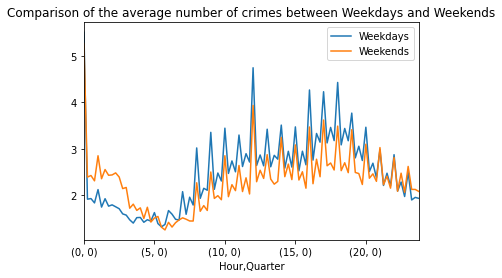

# Distance to the Police Station of the district

## Example of Brighton

Make this Notebook Trusted to load map: File -> Trust Notebook

[interactive chart not shown]

This map shows us that policemen from the station do operates sometimes outside of what is expected of them, but mostly in a delimied radius around the police station (marker).

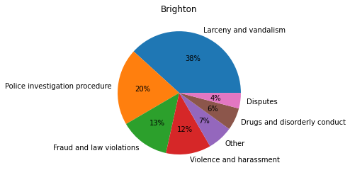

We have here the distribution of type of crimes commited within the Brighton Police Station's juridiction.

## Larceny and Vandalism : First in line

We see that there are more of those crimes in the district of South End, Roxbury and Downtown.

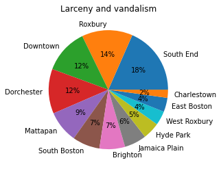

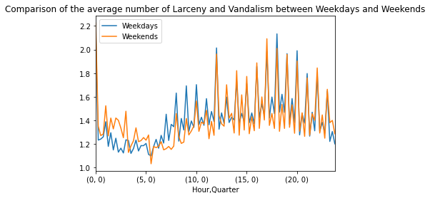